# ANN:CHEP 898

Harsimran Ghai

2026-04-14

my github link is https://github.com/harsimranghai91-eng/ANN-CHEP-898.git

# Loading the Libraries

```r
library(tidyverse)
library(tidymodels)
```

```r
library(sjPlot)
library(finalfit)
library(knitr)
library(gtsummary)
library(mlbench)
library(vip)
library(microbenchmark)
library(AppliedPredictiveModeling)
library(brulee)
library(reportRmd)
library(neuralnet)
```

# Install and Load Torch

```r
if (!torch::torch_is_installed()) {
  torch::install_torch()
}
library(torch)
```

# Research Objectives

Using the artifical neural network to predict stroke diagnosis

# Exploratory data analysis

## Reading in data and formatting

Here are reading in data and getting organized to run our models.

```r
data <- read_csv("canpath_imputed.csv")
data <- data %>% mutate_at(3, factor)
data <- data %>% mutate_at(5:6, factor)
data <- data %>% mutate_at(8:9, factor)
data <- data %>% mutate_at(12:12, factor)
data <- data %>% mutate_at(15:81, factor)
data <- data %>% mutate_at(83:93, factor)

table(data$DIS_DIAB_EVER)
```

```
##
##     0     1     2
## 36714  3114  1359
```

```r
data <- data %>%
  mutate(
    stroke = case_when(
      DIS_STROKE_EVER == 0 ~ 0,
      DIS_STROKE_EVER == 1 ~ 1,
      DIS_STROKE_EVER == 2 ~ 0
    ),
    diabetes = case_when(
      DIS_DIAB_EVER == 0 ~ 0,
      DIS_DIAB_EVER == 1 ~ 1,
      DIS_DIAB_EVER == 2 ~ 0
    ),
    hypertension = case_when(
      DIS_HBP_EVER == 0 ~ 0,
      DIS_HBP_EVER == 1 ~ 1,
      DIS_HBP_EVER == 2 ~ 0
    ),
    depression = case_when(
      DIS_DEP_EVER == 0 ~ 0,
      DIS_DEP_EVER == 1 ~ 1,
      DIS_DEP_EVER == 2 ~ 0
    )
  ) %>%
  mutate(
    stroke = as.factor(stroke),
    diabetes = as.factor(diabetes),
    hypertension = as.factor(hypertension),
    depression = as.factor(depression)
  )


table(data$DIS_STROKE_EVER, data$stroke)
```

```
##
##         0     1
##   0 38416     0
##   1     0   567
##   2  2204     0
```

```r
data$DIS_STROKE_EVER <- NULL
```

```r
data_continuous <- select(data, stroke,
                            PSE_ADULT_WRK_DURATION,
                            PM_BMI_SR,
                            PA_TOTAL_SHORT,
                            SDC_HOUSEHOLD_CHILDREN_NB,
                            SDC_HOUSEHOLD_ADULTS_NB,
                            SDC_EDU_LEVEL_AGE,
                            SDC_AGE_CALC,
                            SDC_GENDER,
                          hypertension,
                          diabetes,
                          depression)
```

## Descriptives

```r
summary(data_continuous)
```

```
##  stroke    PSE_ADULT_WRK_DURATION   PM_BMI_SR     PA_TOTAL_SHORT
##  0:40620   Min.   : 0.000         Min.   : 8.86   Min.   :    0
##  1:  567   1st Qu.: 0.000         1st Qu.:23.41   1st Qu.:  600
##            Median : 2.000         Median :26.62   Median : 1800
##            Mean   : 6.687         Mean   :27.66   Mean   : 2606
##            3rd Qu.:10.000         3rd Qu.:30.68   3rd Qu.: 3795
##            Max.   :51.000         Max.   :69.40   Max.   :19278
##  SDC_HOUSEHOLD_CHILDREN_NB SDC_HOUSEHOLD_ADULTS_NB SDC_EDU_LEVEL_AGE
##  Min.   : 0.0000           Min.   : 1.000          Min.   :-7.00
##  1st Qu.: 0.0000           1st Qu.: 2.000          1st Qu.:19.00
##  Median : 0.0000           Median : 2.000          Median :23.00
##  Mean   : 0.5509           Mean   : 2.077          Mean   :25.34
##  3rd Qu.: 1.0000           3rd Qu.: 2.000          3rd Qu.:28.00
##  Max.   :10.0000           Max.   :21.000          Max.   :73.00
##   SDC_AGE_CALC   SDC_GENDER hypertension diabetes  depression
##  Min.   :30.00   1:15200    0:31265      0:38073   0:36051
##  1st Qu.:43.00   2:25987    1: 9922      1: 3114   1: 5136
##  Median :52.00
##  Mean   :51.48
##  3rd Qu.:60.00
##  Max.   :74.00
```

## Checking missing values

```r
sum(is.na(data_continuous))
```

```
## [1] 0
```

No missing value is found.

# Artifical Neural Network

## Creating training and testing data

```r
set.seed(10)

#### Cross Validation Split
cv_split <- initial_validation_split(data_continuous,
                            strata = stroke,
                            prop = c(0.70, 0.20))

# Create data frames for the two sets:
train_data <- training(cv_split)
table(train_data$stroke)
```

```
##
##     0     1
## 28425   405
```

```r
test_data  <- testing(cv_split)
table(test_data$stroke)
```

```
##
##    0    1
## 4068   51
```

## V-folds

```r
folds <- vfold_cv(training(cv_split), v = 3, strata = stroke)
```

## Creating the Recipe

```r
stroke_recipe <-
  recipe(stroke ~ ., data = train_data) %>%
  step_dummy(all_nominal_predictors()) %>%
  step_zv(all_predictors(), -all_outcomes()) %>%
  step_normalize(all_numeric_predictors())
```

## Basic Model

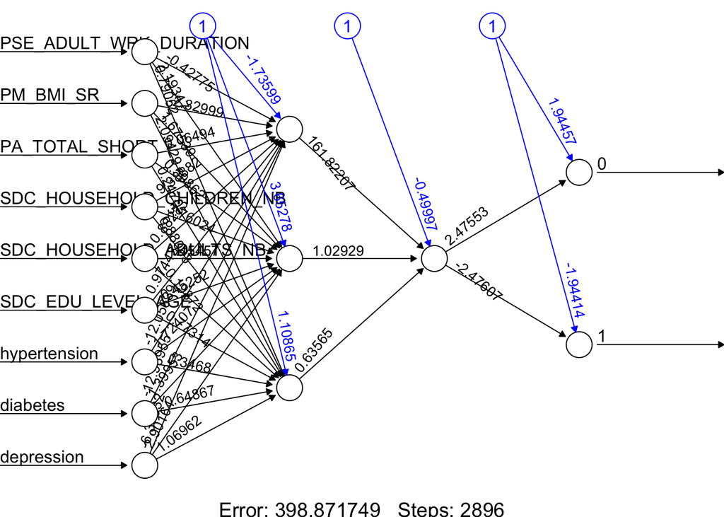

```r
# Converting variables into numeric
train_data$hypertension <- as.numeric(as.character(train_data$hypertension))
train_data$diabetes     <- as.numeric(as.character(train_data$diabetes))
train_data$depression   <- as.numeric(as.character(train_data$depression))

# Running the model
basic_ann <- neuralnet(stroke ~ PSE_ADULT_WRK_DURATION +
                            PM_BMI_SR +
                            PA_TOTAL_SHORT +
                            SDC_HOUSEHOLD_CHILDREN_NB +
                            SDC_HOUSEHOLD_ADULTS_NB +
                            SDC_EDU_LEVEL_AGE+
                       hypertension+
                         diabetes+
                         depression,
                data = train_data,
                hidden = c(3, 1),
                linear.output = FALSE
                )

plot(basic_ann, rep = "best")
```

## TidyModels ANN

```r
set.seed(123)

mlp_model <- mlp(epochs = tune(),
                 hidden_units = tune(),
                 penalty = tune(),
                 learn_rate = tune(),
                 activation = tune()) %>%
                  set_engine("brulee", validation = 0) %>%
                  set_mode("classification")
```

### Workflow

```r
mlp_workflow <-
  workflow() %>%
  add_model(mlp_model) %>%
  add_recipe(stroke_recipe) %>%
    tune_grid(resamples = folds,
                control = control_grid(save_pred = TRUE,
                verbose = TRUE))
```

```
## i Fold1: preprocessor 1/1
```

```
## i Fold1: preprocessor 1/1, model 1/10
```

```
## i Fold1: preprocessor 1/1, model 1/10 (predictions)
```

```
## i Fold1: preprocessor 1/1, model 2/10
```

```
## i Fold1: preprocessor 1/1, model 2/10 (predictions)
```

```
## i Fold1: preprocessor 1/1, model 3/10
```

```
## i Fold1: preprocessor 1/1, model 3/10 (predictions)
```

```
## i Fold1: preprocessor 1/1, model 4/10
```

```
## i Fold1: preprocessor 1/1, model 4/10 (predictions)
```

```
## i Fold1: preprocessor 1/1, model 5/10
```

```
## i Fold1: preprocessor 1/1, model 5/10 (predictions)
```

```
## i Fold1: preprocessor 1/1, model 6/10
```

```
## i Fold1: preprocessor 1/1, model 6/10 (predictions)
```

```
## i Fold1: preprocessor 1/1, model 7/10
```

```
## i Fold1: preprocessor 1/1, model 7/10 (predictions)
```

```
## i Fold1: preprocessor 1/1, model 8/10
```

```
## i Fold1: preprocessor 1/1, model 8/10 (predictions)
```

```
## i Fold1: preprocessor 1/1, model 9/10
```

```
## i Fold1: preprocessor 1/1, model 9/10 (predictions)
```

```
## i Fold1: preprocessor 1/1, model 10/10
```

```
## i Fold1: preprocessor 1/1, model 10/10 (predictions)
```

```
## i Fold2: preprocessor 1/1
```

```
## i Fold2: preprocessor 1/1, model 1/10
```

```
## i Fold2: preprocessor 1/1, model 1/10 (predictions)
```

```
## i Fold2: preprocessor 1/1, model 2/10
```

```
## i Fold2: preprocessor 1/1, model 2/10 (predictions)
```

```
## i Fold2: preprocessor 1/1, model 3/10
```

```
## i Fold2: preprocessor 1/1, model 3/10 (predictions)
```

```
## i Fold2: preprocessor 1/1, model 4/10
```

```
## i Fold2: preprocessor 1/1, model 4/10 (predictions)
```

```
## i Fold2: preprocessor 1/1, model 5/10
```

```
## i Fold2: preprocessor 1/1, model 5/10 (predictions)
```

```
## i Fold2: preprocessor 1/1, model 6/10
```

```
## i Fold2: preprocessor 1/1, model 6/10 (predictions)
```

```
## i Fold2: preprocessor 1/1, model 7/10
```

```
## i Fold2: preprocessor 1/1, model 7/10 (predictions)
```

```
## i Fold2: preprocessor 1/1, model 8/10
```

```
## i Fold2: preprocessor 1/1, model 8/10 (predictions)
```

```
## i Fold2: preprocessor 1/1, model 9/10
```

```
## i Fold2: preprocessor 1/1, model 9/10 (predictions)
```

```
## i Fold2: preprocessor 1/1, model 10/10
```

```
## i Fold2: preprocessor 1/1, model 10/10 (predictions)
```

```
## i Fold3: preprocessor 1/1
```

```
## i Fold3: preprocessor 1/1, model 1/10
```

```
## i Fold3: preprocessor 1/1, model 1/10 (predictions)
```

```
## i Fold3: preprocessor 1/1, model 2/10
```

```
## i Fold3: preprocessor 1/1, model 2/10 (predictions)
```

```
## i Fold3: preprocessor 1/1, model 3/10
```

```
## i Fold3: preprocessor 1/1, model 3/10 (predictions)
```

```
## i Fold3: preprocessor 1/1, model 4/10
```

```
## i Fold3: preprocessor 1/1, model 4/10 (predictions)
```

```
## i Fold3: preprocessor 1/1, model 5/10
```

```
## i Fold3: preprocessor 1/1, model 5/10 (predictions)
```

```
## i Fold3: preprocessor 1/1, model 6/10
```

```
## i Fold3: preprocessor 1/1, model 6/10 (predictions)
```

```
## i Fold3: preprocessor 1/1, model 7/10
```

```
## i Fold3: preprocessor 1/1, model 7/10 (predictions)
```

```
## i Fold3: preprocessor 1/1, model 8/10
```

```
## i Fold3: preprocessor 1/1, model 8/10 (predictions)
```

```
## i Fold3: preprocessor 1/1, model 9/10
```

```
## i Fold3: preprocessor 1/1, model 9/10 (predictions)
```

```
## i Fold3: preprocessor 1/1, model 10/10
```

```
## i Fold3: preprocessor 1/1, model 10/10 (predictions)
```

### Workflow results

```r
metrics_tune <- collect_metrics(mlp_workflow)

show_best(mlp_workflow, metric='accuracy', n=5)
```

```
## # A tibble: 5 × 11
##   hidden_units     penalty epochs activation learn_rate .metric .estimator  mean
##          <int>       <dbl>  <int> <chr>           <dbl> <chr>   <chr>      <dbl>
## 1            7     2.15e-7    115 relu          0.001   accura… binary     0.986
## 2           50     1.67e-8     60 log_sigmo…    0.0176  accura… binary     0.986
## 3           23     7.74e-2      5 tanh          0.0736  accura… binary     0.986
## 4           28     1.29e-9    500 log_sigmo…    0.00858 accura… binary     0.986
## 5            2     5.99e-3    445 tanh          0.0359  accura… binary     0.986
## # ℹ 3 more variables: n <int>, std_err <dbl>, .config <chr>
```

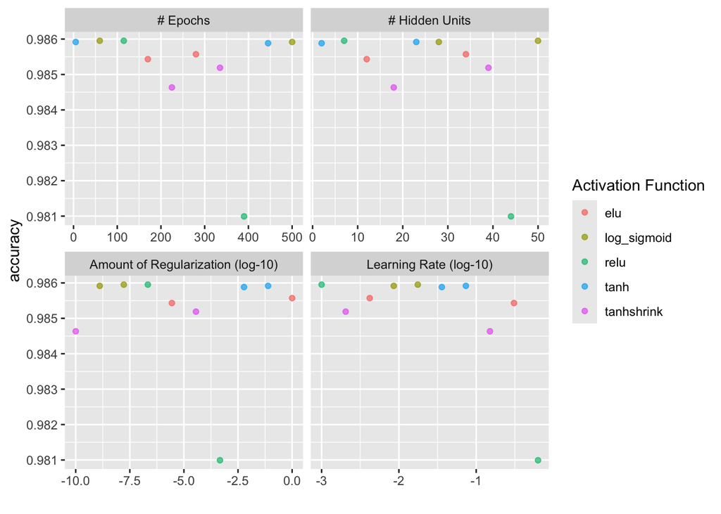

```r
plot(autoplot(mlp_workflow, metric = 'accuracy'))
```

### Final model - Test data

```r
mlp_best <-
  mlp_workflow %>%
  select_best(metric = "accuracy")

mlp_final_model <- finalize_model(
                          mlp_model,
                          mlp_best
                          )
mlp_final_model
```

```
## Single Layer Neural Network Model Specification (classification)
##
## Main Arguments:
##   hidden_units = 7
##   penalty = 2.15443469003189e-07
##   epochs = 115
##   activation = relu
##   learn_rate = 0.001
##
## Engine-Specific Arguments:
##   validation = 0
##
## Computational engine: brulee
```

```r
final_mlp_workflow <- workflow() %>%
                      add_recipe(stroke_recipe) %>%
                      add_model(mlp_final_model)

final_mlp_results <- final_mlp_workflow %>%
                    last_fit(cv_split)

mlp_results <- final_mlp_results %>% collect_metrics()
```

## Final Results

```r
kable(mlp_results)
```

| .metric | .estimator | .estimate | .config |
| --- | --- | --- | --- |
| accuracy | binary | 0.9876184 | pre0_mod0_post0 |
| roc_auc | binary | 0.6237974 | pre0_mod0_post0 |
| brier_class | binary | 0.0122243 | pre0_mod0_post0 |

## Two Layer ANN

```r
set.seed(123)

mlp_model_2l <- mlp(epochs = tune(),
                    hidden_units = tune(),
                    penalty = tune(),
                    learn_rate = tune(),
                    activation = tune()) %>%
                 set_engine("brulee_two_layer",
                   hidden_units_2 = tune(),
                   activation_2 = tune()) %>%
                 set_mode("classification")
```

### Workflow

```r
### Takes around 5minutes to run

mlp_workflow_2l <-
  workflow() %>%
  add_model(mlp_model_2l) %>%
  add_recipe(stroke_recipe) %>%
    tune_grid(resamples = folds,
                control = control_grid(save_pred = TRUE,
                verbose = TRUE))
```

```
## i Fold1: preprocessor 1/1
```

```
## i Fold1: preprocessor 1/1, model 1/10
```

```
## i Fold1: preprocessor 1/1, model 1/10 (predictions)
```

```
## i Fold1: preprocessor 1/1, model 2/10
```

```
## i Fold1: preprocessor 1/1, model 2/10 (predictions)
```

```
## i Fold1: preprocessor 1/1, model 3/10
```

```
## i Fold1: preprocessor 1/1, model 3/10 (predictions)
```

```
## i Fold1: preprocessor 1/1, model 4/10
```

```
## i Fold1: preprocessor 1/1, model 4/10 (predictions)
```

```
## i Fold1: preprocessor 1/1, model 5/10
```

```
## i Fold1: preprocessor 1/1, model 5/10 (predictions)
```

```
## i Fold1: preprocessor 1/1, model 6/10
```

```
## i Fold1: preprocessor 1/1, model 6/10 (predictions)
```

```
## i Fold1: preprocessor 1/1, model 7/10
```

```
## i Fold1: preprocessor 1/1, model 7/10 (predictions)
```

```
## i Fold1: preprocessor 1/1, model 8/10
```

```
## i Fold1: preprocessor 1/1, model 8/10 (predictions)
```

```
## i Fold1: preprocessor 1/1, model 9/10
```

```
## i Fold1: preprocessor 1/1, model 9/10 (predictions)
```

```
## i Fold1: preprocessor 1/1, model 10/10
```

```
## i Fold1: preprocessor 1/1, model 10/10 (predictions)
```

```
## i Fold2: preprocessor 1/1
```

```
## i Fold2: preprocessor 1/1, model 1/10
```

```
## i Fold2: preprocessor 1/1, model 1/10 (predictions)
```

```
## i Fold2: preprocessor 1/1, model 2/10
```

```
## i Fold2: preprocessor 1/1, model 2/10 (predictions)
```

```
## i Fold2: preprocessor 1/1, model 3/10
```

```
## i Fold2: preprocessor 1/1, model 3/10 (predictions)
```

```
## i Fold2: preprocessor 1/1, model 4/10
```

```
## i Fold2: preprocessor 1/1, model 4/10 (predictions)
```

```
## i Fold2: preprocessor 1/1, model 5/10
```

```
## i Fold2: preprocessor 1/1, model 5/10 (predictions)
```

```
## i Fold2: preprocessor 1/1, model 6/10
```

```
## i Fold2: preprocessor 1/1, model 6/10 (predictions)
```

```
## i Fold2: preprocessor 1/1, model 7/10
```

```
## i Fold2: preprocessor 1/1, model 7/10 (predictions)
```

```
## i Fold2: preprocessor 1/1, model 8/10
```

```
## i Fold2: preprocessor 1/1, model 8/10 (predictions)
```

```
## i Fold2: preprocessor 1/1, model 9/10
```

```
## i Fold2: preprocessor 1/1, model 9/10 (predictions)
```

```
## i Fold2: preprocessor 1/1, model 10/10
```

```
## i Fold2: preprocessor 1/1, model 10/10 (predictions)
```

```
## i Fold3: preprocessor 1/1
```

```
## i Fold3: preprocessor 1/1, model 1/10
```

```
## i Fold3: preprocessor 1/1, model 1/10 (predictions)
```

```
## i Fold3: preprocessor 1/1, model 2/10
```

```
## i Fold3: preprocessor 1/1, model 2/10 (predictions)
```

```
## i Fold3: preprocessor 1/1, model 3/10
```

```
## i Fold3: preprocessor 1/1, model 3/10 (predictions)
```

```
## i Fold3: preprocessor 1/1, model 4/10
```

```
## i Fold3: preprocessor 1/1, model 4/10 (predictions)
```

```
## i Fold3: preprocessor 1/1, model 5/10
```

```
## i Fold3: preprocessor 1/1, model 5/10 (predictions)
```

```
## i Fold3: preprocessor 1/1, model 6/10
```

```
## i Fold3: preprocessor 1/1, model 6/10 (predictions)
```

```
## i Fold3: preprocessor 1/1, model 7/10
```

```
## i Fold3: preprocessor 1/1, model 7/10 (predictions)
```

```
## i Fold3: preprocessor 1/1, model 8/10
```

```
## i Fold3: preprocessor 1/1, model 8/10 (predictions)
```

```
## i Fold3: preprocessor 1/1, model 9/10
```

```
## i Fold3: preprocessor 1/1, model 9/10 (predictions)
```

```
## i Fold3: preprocessor 1/1, model 10/10
```

```
## i Fold3: preprocessor 1/1, model 10/10 (predictions)
```

### Workflow results

```r
metrics_tune_2l <- collect_metrics(mlp_workflow_2l)

show_best(mlp_workflow_2l, metric='accuracy', n=5)  # only show the results for the best 5 models
```

```
## # A tibble: 5 × 13
##   hidden_units  penalty epochs activation learn_rate hidden_units_2 activation_2
##          <int>    <dbl>  <int> <chr>           <dbl>          <int> <chr>
## 1            2 1   e+ 0    280 log_sigmo…    0.151               34 tanh
## 2           12 1   e-10    445 tanh          0.308               23 relu
## 3           18 3.59e- 5    170 elu           0.00419             39 elu
## 4           23 4.64e- 4      5 tanhshrink    0.0736              12 elu
## 5           28 1.29e- 9    115 tanh          0.00205             44 tanhshrink
## # ℹ 6 more variables: .metric <chr>, .estimator <chr>, mean <dbl>, n <int>,
## #   std_err <dbl>, .config <chr>
```

### Final model - Test data

```r
mlp_best_2l <-
  mlp_workflow_2l %>%
  select_best(metric = "accuracy")

mlp_final_model_2l <- finalize_model(
                          mlp_model_2l,
                          mlp_best_2l
                          )
mlp_final_model_2l
```

```
## Single Layer Neural Network Model Specification (classification)
##
## Main Arguments:
##   hidden_units = 2
##   penalty = 1
##   epochs = 280
##   activation = log_sigmoid
##   learn_rate = 0.150583635427984
##
## Engine-Specific Arguments:
##   hidden_units_2 = 34
##   activation_2 = tanh
##
## Computational engine: brulee_two_layer
```

```r
final_mlp_workflow_2l <- workflow() %>%
                      add_recipe(stroke_recipe) %>%
                      add_model(mlp_final_model_2l)

final_mlp_results_2l <- final_mlp_workflow_2l %>%
                        last_fit(cv_split)

mlp_results_2l <- final_mlp_results_2l %>% collect_metrics()
```

## Final Results

```r
kable(mlp_results_2l)
```

| .metric | .estimator | .estimate | .config |
| --- | --- | --- | --- |
| accuracy | binary | 0.9876184 | pre0_mod0_post0 |
| roc_auc | binary | 0.6178832 | pre0_mod0_post0 |
| brier_class | binary | 0.0122254 | pre0_mod0_post0 |

## Final Results

```r
kable(mlp_results)
```

| .metric | .estimator | .estimate | .config |
| --- | --- | --- | --- |
| accuracy | binary | 0.9876184 | pre0_mod0_post0 |
| roc_auc | binary | 0.6237974 | pre0_mod0_post0 |
| brier_class | binary | 0.0122243 | pre0_mod0_post0 |

# Model Comparison and Reasoning

The accuracy of two layer ANN is 98.76 and ROC is 61.78. In comparison to the single layer ANN, the accuracy of the two models are same but the ROC-AUC is less for the two layer model. Two layer ANN performed worse than than the single layer ANN. The reason behind this can be 1. Class imbalance 2. Overfitting in the complex model 3. Low sample size

## Variable Importance

Feature importance is not available for the ANN as the weights assigned in ANN does not reflect importance,secondly, the inputs are transformed multiple times and scaling changes the weight magnitude completely. However, I believe that there are some indirect ways to get variable importance in ANN, which I need to explore further, but I am not sure.